# 8_bis_Emission_Analysis_high_level

2025-10-28

# A Productivity–Emission Relationship Analysis

To characterize the relationship between animal productivity and methane emissions across ruminant production systems, we compiled experimental data from controlled feeding studies reporting both daily product yield and annual methane output per animal. Each observation represented a discrete diet treatment within a study, identified by a unique study identifier code. Productivity metrics were standardized to edible product yield, expressed as either milk yield (kg animal⁻¹ day⁻¹) or meat yield derived from carcass composition or growth rate measurements. Methane emissions were standardized to annual production (kg CH₄ animal⁻¹ yr⁻¹). Linear regression models were fitted independently for each species × product combination to quantify the relationship between productivity and absolute methane emissions. This approach captured within-study scaling relationships while maintaining comparability across experimental contexts. The analysis was restricted to genuine production outputs (milk or meat) to exclude potentially confounding metrics such as live weight gain or feed intake. Each regression coefficient therefore represents the empirical association between productivity and emission intensity across dietary treatments within comparable experimental frameworks. The resulting relationships (Figure 1) illustrate how improvements in production output correspond to changes in total methane emission at the animal scale, providing cross-species visualization of productivity–emission trade-offs. By employing experimental contrasts rather than aggregated national inventory data, this analytical framework isolated biological variation in feed efficiency from management- or system-level effects.

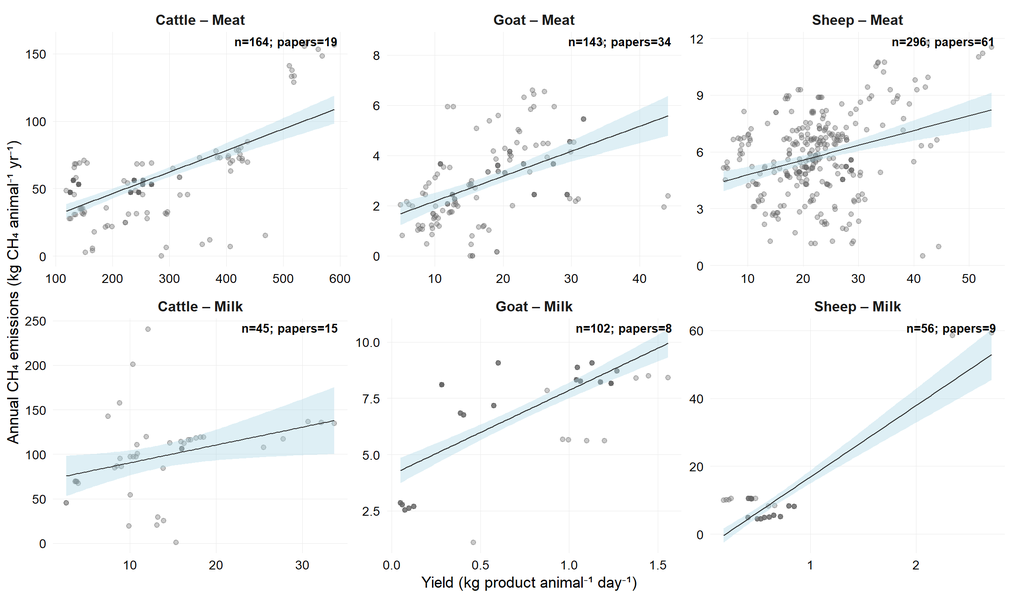

```
## [1] 146
```

# B Nutrient–Response Model Development

## Within-Study Comparative Framework

We quantify how **observed diet shifts** affect **enteric methane (CH₄), product yield (Y), and emission intensity (EI = CH₄/Y)** using a strictly **within-study** design that controls for all between-study differences (genetics, climate, management, instrumentation). For each study × outcome, we select a **single reference diet** using a transparent rule:

1. If any treatment is flagged **CONTROL**, that treatment is the reference;
2. Otherwise, the **first reported** treatment is used.

All other treatments in that study are then expressed **relative to the reference**. This produces paired within-study contrasts for responses:

- **Percent changes**: ΔCH₄ (%) = 100·(CH₄ − CH₄_ref)/CH₄_ref;  
  ΔY (%) = 100·(Y − Y_ref)/Y_ref;  
  ΔEI (%) = 100·(EI − EI_ref)/EI_ref,
- **Log-ratios (recommended primary scale)**:  
  lnCH₄ = ln(CH₄/CH₄_ref), lnY = ln(Y/Y_ref), and  
  **lnEI = lnCH₄ − lnY** (by identity, since EI = CH₄/Y).

Log-ratios provide **scale invariance**, symmetric up/down effects, and naturally map coefficients back to **percent changes** via $100\,[\exp(\beta) - 1]$.

For predictors, we compute within-study **nutrient deltas** between each diet and the reference for: metabolizable energy (ME), neutral detergent fibre (NDF), crude protein (CP), and ether extract (EE). To ensure interpretable slopes and to reflect realistic formulation steps in the dataset, we **standardize units** as: - **ΔME** per **1 MJ·kg⁻¹ DM**,  
- **ΔNDF** per **100 g·kg⁻¹ DM**,  
- **ΔCP** per **50 g·kg⁻¹ DM**,  
- **ΔEE** per **10 g·kg⁻¹ DM**.

This normalization means each coefficient can be read as the expected change in the outcome for a **typical, feasible** change in diet composition.

## Statistical Modeling Approach (Linear Models)

We fit ordinary least-squares (OLS) models **separately within each species × product stratum** (cattle/sheep/goat × milk/meat) to preserve species- and system-specific biology. For each stratum and each outcome, we estimate two closely related specifications:

1. **Percent-change model (Δ-scale):**
   $$\Delta\% \;=\; \beta_0 + \beta_{\text{ME}}\Delta\text{ME} +
   \beta_{\text{NDF}}\Delta\text{NDF} + \beta_{\text{CP}}\Delta\text{CP} +
   \beta_{\text{EE}}\Delta\text{EE} + \varepsilon.$$
2. **Log-ratio model (primary, recommended):**
   $$\ln R \;=\; \beta_0 + \beta_{\text{ME}}\Delta\text{ME} +
   \beta_{\text{NDF}}\Delta\text{NDF} + \beta_{\text{CP}}\Delta\text{CP} +
   \beta_{\text{EE}}\Delta\text{EE} + \varepsilon,$$
   where $R \in \{\mathrm{CH_4}, Y, \mathrm{EI}\}$ and **$\ln \mathrm{EI} = \ln \mathrm{CH_4} - \ln Y$**.

This linear-on-logs approach retains the **design-based control** of the within-study framework while yielding **directly interpretable elasticities**: e.g., the coefficient on ΔME gives the **percent change** in CH₄ (or Y, or EI) for a +1 MJ·kg⁻¹ DM shift in ME relative to the study’s reference diet.

## Presentation of Species- and System-Specific Patterns

Results are presented as compact coefficient plots:

Because all effects are estimated from **within-study** contrasts, coefficients reflect **biological response to diet composition** rather than confounding from study-level context. Unit scaling (ME: +1; NDF: +100; CP: +50; EE: +10) aligns with observed contrasts in African feeding trials, ensuring results correspond to **feasible formulation moves**.

## Why the Log-Ratio Linear Model is Preferred

While percent-change models are intuitive, the **log-ratio specification** is preferred for three reasons:

1. **Symmetry and coherence:** proportional increases and decreases are treated symmetrically; compounding is handled correctly.
2. **Scale invariance:** coefficients are comparable across studies with different baselines.
3. **Direct EI identity:** modeling lnCH₄ and lnY implies lnEI **by construction** ($\ln\mathrm{EI}=\ln\mathrm{CH_4}-\ln Y$), enhancing internal consistency.

Together, the updated **reference-aware** contrasts and the **log-ratio linear models** deliver estimates that are **comparable, interpretable, and robust** to between-study heterogeneity—ideal for extracting policy-relevant patterns from heterogeneous experimental evidence.

```
## `height` was translated to `width`.
## `height` was translated to `width`.
## `height` was translated to `width`.
```

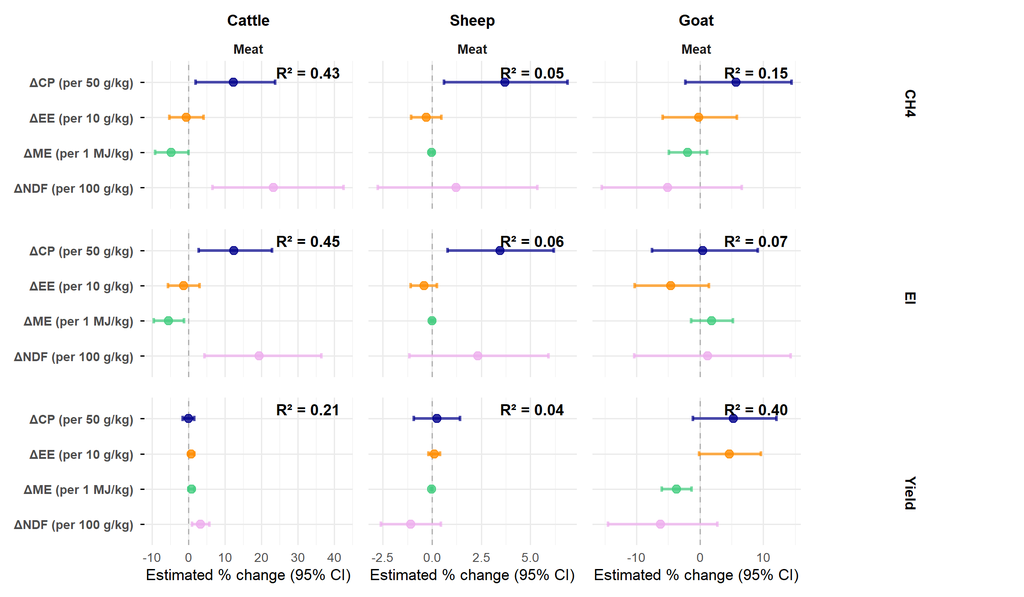

```
## `height` was translated to `width`.
## `height` was translated to `width`.
## `height` was translated to `width`.
```

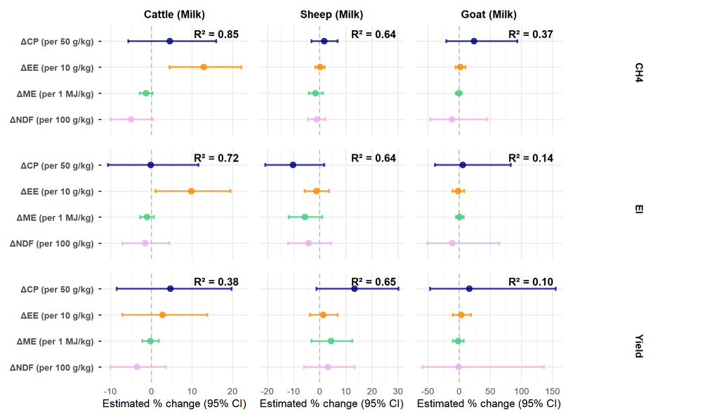

## b.1 Number of observations for models

UNIQUE counts per Nutrient × Outcome × Species × Product (log outcomes)

| Species | Product | Outcome | Nutrient | n_obs_unique | n_papers_unique |
| --- | --- | --- | --- | --- | --- |
| Cattle | Milk | CH₄ (log-ratio) | ΔCP (per 50 g/kg) | 19 | 7 |
| Cattle | Milk | CH₄ (log-ratio) | ΔEE (per 10 g/kg) | 19 | 7 |
| Cattle | Milk | CH₄ (log-ratio) | ΔME (per 1 MJ/kg) | 17 | 6 |
| Cattle | Milk | CH₄ (log-ratio) | ΔNDF (per 100 g/kg) | 19 | 7 |
| Cattle | Milk | EI (log-ratio) | ΔCP (per 50 g/kg) | 19 | 7 |
| Cattle | Milk | EI (log-ratio) | ΔEE (per 10 g/kg) | 19 | 7 |
| Cattle | Milk | EI (log-ratio) | ΔME (per 1 MJ/kg) | 17 | 6 |
| Cattle | Milk | EI (log-ratio) | ΔNDF (per 100 g/kg) | 19 | 7 |
| Cattle | Milk | Yield (log-ratio) | ΔCP (per 50 g/kg) | 19 | 7 |
| Cattle | Milk | Yield (log-ratio) | ΔEE (per 10 g/kg) | 19 | 7 |
| Cattle | Milk | Yield (log-ratio) | ΔME (per 1 MJ/kg) | 17 | 6 |
| Cattle | Milk | Yield (log-ratio) | ΔNDF (per 100 g/kg) | 19 | 7 |
| Cattle | Meat | CH₄ (log-ratio) | ΔCP (per 50 g/kg) | 67 | 17 |
| Cattle | Meat | CH₄ (log-ratio) | ΔEE (per 10 g/kg) | 67 | 17 |
| Cattle | Meat | CH₄ (log-ratio) | ΔME (per 1 MJ/kg) | 56 | 13 |
| Cattle | Meat | CH₄ (log-ratio) | ΔNDF (per 100 g/kg) | 67 | 17 |
| Cattle | Meat | EI (log-ratio) | ΔCP (per 50 g/kg) | 67 | 17 |
| Cattle | Meat | EI (log-ratio) | ΔEE (per 10 g/kg) | 67 | 17 |
| Cattle | Meat | EI (log-ratio) | ΔME (per 1 MJ/kg) | 56 | 13 |
| Cattle | Meat | EI (log-ratio) | ΔNDF (per 100 g/kg) | 67 | 17 |
| Cattle | Meat | Yield (log-ratio) | ΔCP (per 50 g/kg) | 67 | 17 |
| Cattle | Meat | Yield (log-ratio) | ΔEE (per 10 g/kg) | 67 | 17 |
| Cattle | Meat | Yield (log-ratio) | ΔME (per 1 MJ/kg) | 56 | 13 |
| Cattle | Meat | Yield (log-ratio) | ΔNDF (per 100 g/kg) | 67 | 17 |
| Sheep | Milk | CH₄ (log-ratio) | ΔCP (per 50 g/kg) | 14 | 8 |
| Sheep | Milk | CH₄ (log-ratio) | ΔEE (per 10 g/kg) | 14 | 8 |
| Sheep | Milk | CH₄ (log-ratio) | ΔME (per 1 MJ/kg) | 12 | 6 |
| Sheep | Milk | CH₄ (log-ratio) | ΔNDF (per 100 g/kg) | 14 | 8 |
| Sheep | Milk | EI (log-ratio) | ΔCP (per 50 g/kg) | 14 | 8 |
| Sheep | Milk | EI (log-ratio) | ΔEE (per 10 g/kg) | 14 | 8 |
| Sheep | Milk | EI (log-ratio) | ΔME (per 1 MJ/kg) | 12 | 6 |
| Sheep | Milk | EI (log-ratio) | ΔNDF (per 100 g/kg) | 14 | 8 |
| Sheep | Milk | Yield (log-ratio) | ΔCP (per 50 g/kg) | 14 | 8 |
| Sheep | Milk | Yield (log-ratio) | ΔEE (per 10 g/kg) | 14 | 8 |
| Sheep | Milk | Yield (log-ratio) | ΔME (per 1 MJ/kg) | 12 | 6 |
| Sheep | Milk | Yield (log-ratio) | ΔNDF (per 100 g/kg) | 14 | 8 |
| Sheep | Meat | CH₄ (log-ratio) | ΔCP (per 50 g/kg) | 153 | 39 |
| Sheep | Meat | CH₄ (log-ratio) | ΔEE (per 10 g/kg) | 153 | 39 |
| Sheep | Meat | CH₄ (log-ratio) | ΔME (per 1 MJ/kg) | 127 | 31 |
| Sheep | Meat | CH₄ (log-ratio) | ΔNDF (per 100 g/kg) | 152 | 38 |
| Sheep | Meat | EI (log-ratio) | ΔCP (per 50 g/kg) | 153 | 39 |
| Sheep | Meat | EI (log-ratio) | ΔEE (per 10 g/kg) | 153 | 39 |
| Sheep | Meat | EI (log-ratio) | ΔME (per 1 MJ/kg) | 127 | 31 |
| Sheep | Meat | EI (log-ratio) | ΔNDF (per 100 g/kg) | 152 | 38 |
| Sheep | Meat | Yield (log-ratio) | ΔCP (per 50 g/kg) | 153 | 39 |
| Sheep | Meat | Yield (log-ratio) | ΔEE (per 10 g/kg) | 153 | 39 |
| Sheep | Meat | Yield (log-ratio) | ΔME (per 1 MJ/kg) | 127 | 31 |
| Sheep | Meat | Yield (log-ratio) | ΔNDF (per 100 g/kg) | 152 | 38 |
| Goat | Milk | CH₄ (log-ratio) | ΔCP (per 50 g/kg) | 13 | 5 |
| Goat | Milk | CH₄ (log-ratio) | ΔEE (per 10 g/kg) | 13 | 5 |
| Goat | Milk | CH₄ (log-ratio) | ΔME (per 1 MJ/kg) | 11 | 5 |
| Goat | Milk | CH₄ (log-ratio) | ΔNDF (per 100 g/kg) | 13 | 5 |
| Goat | Milk | EI (log-ratio) | ΔCP (per 50 g/kg) | 13 | 5 |
| Goat | Milk | EI (log-ratio) | ΔEE (per 10 g/kg) | 13 | 5 |
| Goat | Milk | EI (log-ratio) | ΔME (per 1 MJ/kg) | 11 | 5 |
| Goat | Milk | EI (log-ratio) | ΔNDF (per 100 g/kg) | 13 | 5 |
| Goat | Milk | Yield (log-ratio) | ΔCP (per 50 g/kg) | 13 | 5 |
| Goat | Milk | Yield (log-ratio) | ΔEE (per 10 g/kg) | 13 | 5 |
| Goat | Milk | Yield (log-ratio) | ΔME (per 1 MJ/kg) | 11 | 5 |
| Goat | Milk | Yield (log-ratio) | ΔNDF (per 100 g/kg) | 13 | 5 |
| Goat | Meat | CH₄ (log-ratio) | ΔCP (per 50 g/kg) | 65 | 23 |
| Goat | Meat | CH₄ (log-ratio) | ΔEE (per 10 g/kg) | 65 | 23 |
| Goat | Meat | CH₄ (log-ratio) | ΔME (per 1 MJ/kg) | 60 | 21 |
| Goat | Meat | CH₄ (log-ratio) | ΔNDF (per 100 g/kg) | 65 | 23 |
| Goat | Meat | EI (log-ratio) | ΔCP (per 50 g/kg) | 65 | 23 |
| Goat | Meat | EI (log-ratio) | ΔEE (per 10 g/kg) | 65 | 23 |
| Goat | Meat | EI (log-ratio) | ΔME (per 1 MJ/kg) | 60 | 21 |
| Goat | Meat | EI (log-ratio) | ΔNDF (per 100 g/kg) | 65 | 23 |
| Goat | Meat | Yield (log-ratio) | ΔCP (per 50 g/kg) | 65 | 23 |
| Goat | Meat | Yield (log-ratio) | ΔEE (per 10 g/kg) | 65 | 23 |
| Goat | Meat | Yield (log-ratio) | ΔME (per 1 MJ/kg) | 60 | 21 |
| Goat | Meat | Yield (log-ratio) | ΔNDF (per 100 g/kg) | 65 | 23 |